# Annexe : code commenté

Ce notebook regroupe l’ensemble du code commenté pour le projet de séries temporelles. Se repporter aux questions correspondantes dans le rapport plus haut pour avoir l’analyse et l’interprétation des résultats. Les pages 9 à 19 rapportent les résultats de l’ensemble des tests pour les sous-modèles, ces pages peuvent donc être sautées lors de la lecture.

```r
#Packages requis
require(fUnitRoots)
require(aTSA)
require(astsa)
#Importations des données
data=read.csv('valeurs_mensuelles.csv',sep=";")
xp.source <- ts(data[[2]]) #données dans la 2e colonne
L <- length(xp.source)
xp <- ts(as.numeric(xp.source[4:L])) #4 premiers éléments h-s
```

#### Q.2 & 3

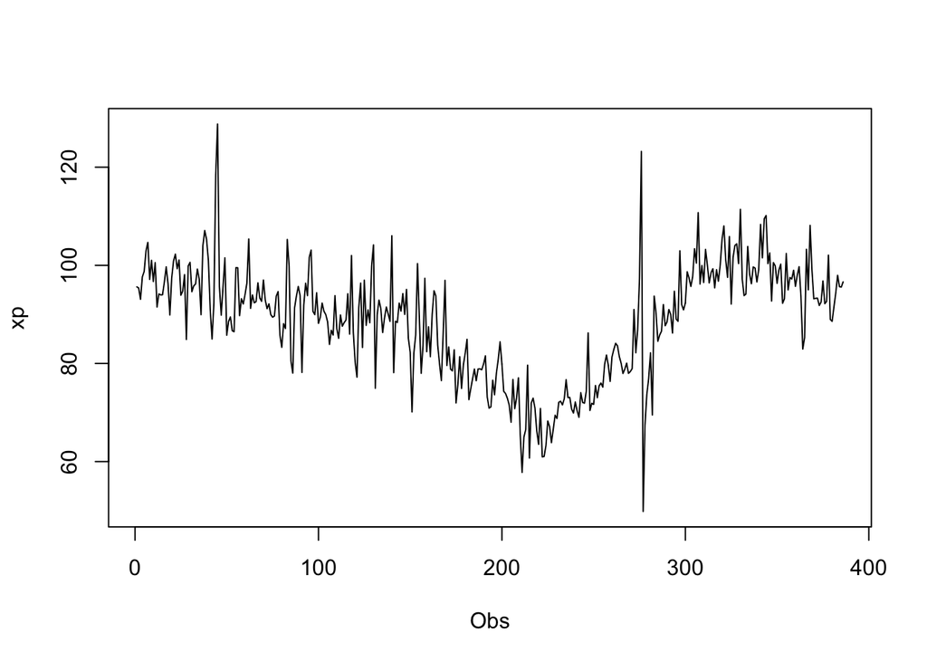

```r
plot(xp,xlab="Obs") #Représentation de la série
```

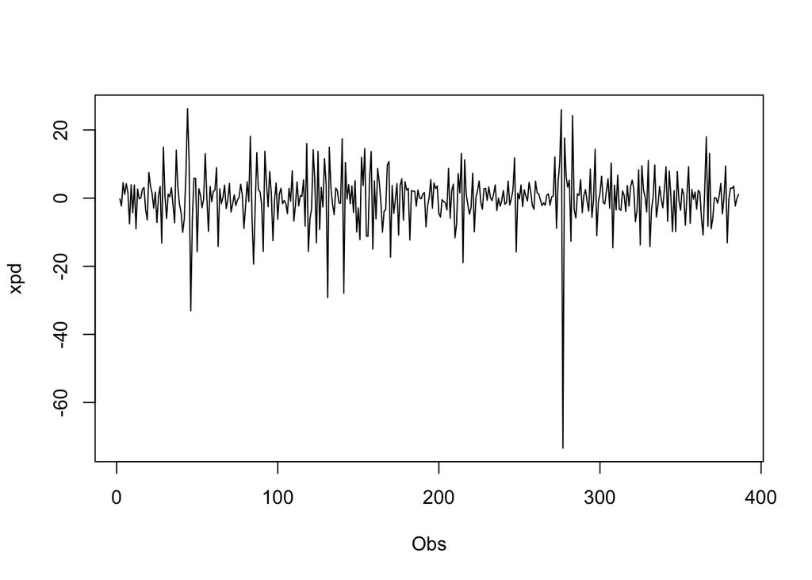

```r
#La série n'a pas l'air stationnaire, on la différencie une fois
xpd <- diff(xp,1)
plot(xpd,xlab="Obs")
```

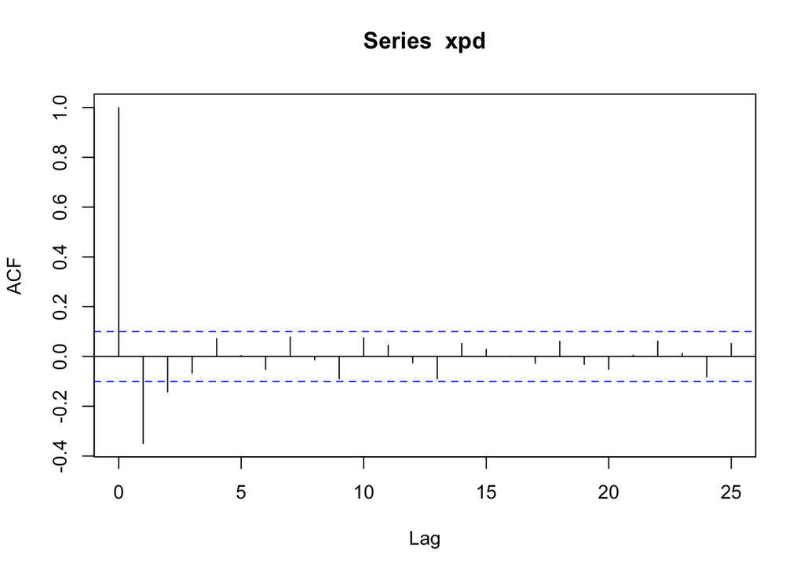

```r
acf(xpd) #Fonction d'autocorrélation totale
```

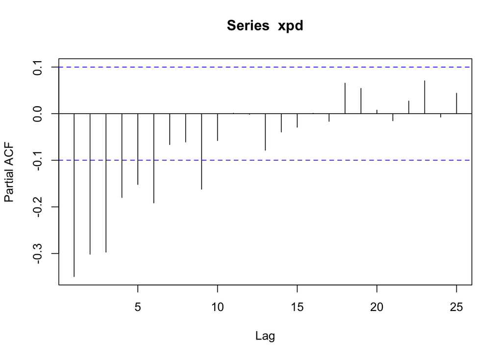

```r
pacf(xpd) #Fonction d'autocorrélation partielle
```

**Test de stationnarité**

```r
# Test de racine unité
adfTest(xpd,lags=0,type="c") #ADF
```

```
##
## Title:
##  Augmented Dickey-Fuller Test
##
## Test Results:
##   PARAMETER:
##     Lag Order: 0
##   STATISTIC:
##     Dickey-Fuller: -28.1527
##   P VALUE:
##     0.01
##
## Description:
##  Wed May 11 09:32:03 2022 by user:
```

```r
stationary.test(xpd,method="pp",type="Z_tau")
```

```
## Phillips-Perron Unit Root Test
## alternative: stationary
##
## Type 1: no drift no trend
##  lag Z_tau p.value
##    5   -40    0.01
## -----
##  Type 2: with drift no trend
##  lag Z_tau p.value
##    5 -39.9    0.01
## -----
##  Type 3: with drift and trend
##  lag Z_tau p.value
##    5 -39.9    0.01
## ---------------
## Note: p-value = 0.01 means p.value <= 0.01
```

```r
#p-value proche de 0 : on rejette l'hypothèse nulle de racine unité
```

**Recherche des ordres p et q**

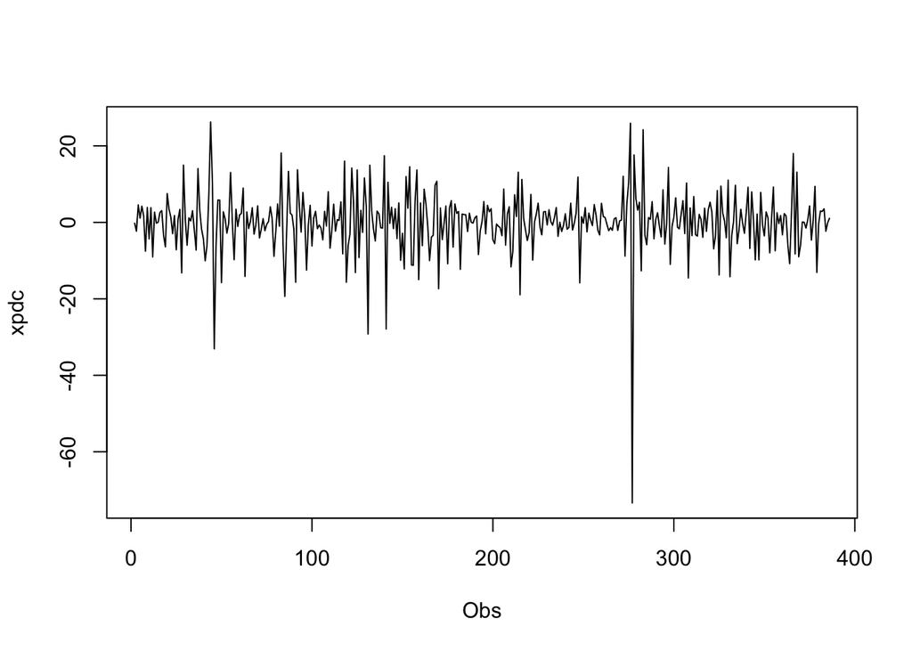

```r
xpdc <- xpd - mean(xpd) #on centre la série
plot(xpdc,xlab="Obs")
```

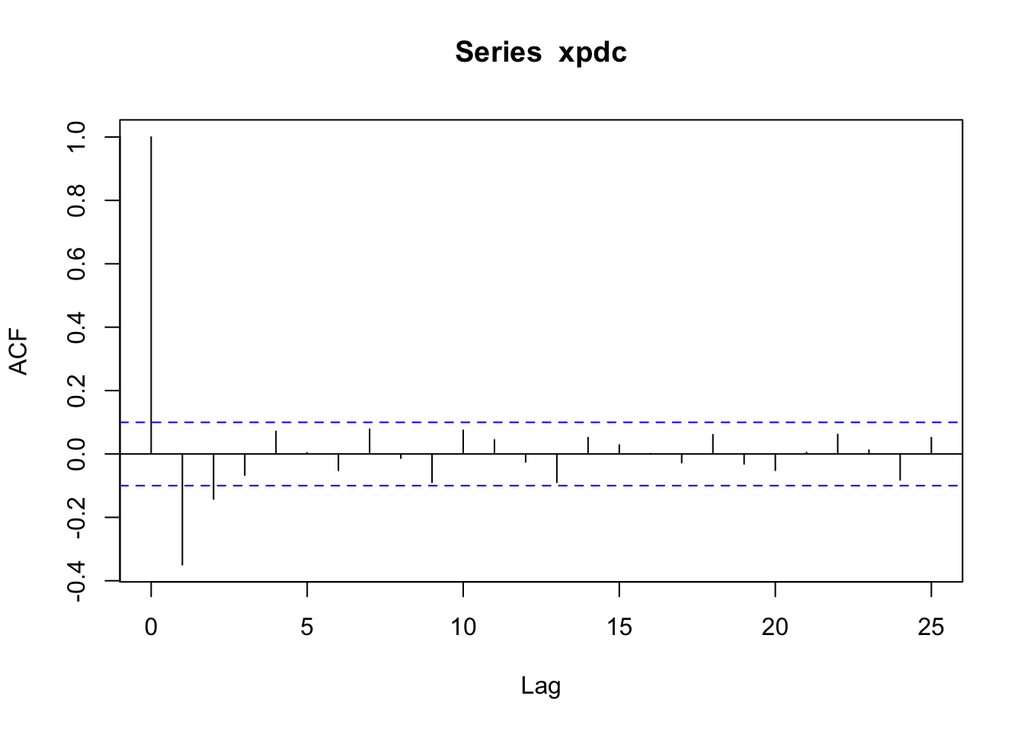

```r
acf(xpdc) #q=2
```

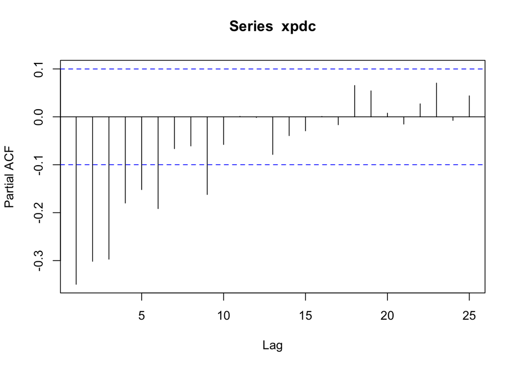

```r
pacf(xpdc) #p=9
```

```r
#Si xpdc suit un ARMA elle suit au plus un ARMA(p=9,q=2)
test92 <- arima(xpdc,order=c(9,0,2),include.mean=FALSE)
```

Commentaires : on doit vérifier que le modèle est valide ie que les résidus ne sont pas autocorrélés. On effectue un test de portemanteau avec statistique de Ljung-Box. On vérifie ensuite que le modèle est bien ajusté en étudiant la significativité à 95% des coefficients des ordres les plus élevés.

#### Q.4

**1.Test d’autocorrélation des résidus**

```r
Box.test(test92$residuals,lag=12,type="Ljung-Box",fitdf=11)
```

```
##
##  Box-Ljung test
##
## data:  test92$residuals
## X-squared = 0.29787, df = 1, p-value = 0.5852
```

```r
# On corrige les degrés de libertés du nombre de régresseurs!p+q=11,
#on ne peut effectuer le test pour lag<12
```

```r
# On crée une fonction pour tester la validité des différents modèles
# (H0) : nullité jointe des autocorrélations des résidus

TestAutocorr<-function(var,p,d,q){
  autocorL<-list()
  fitdf<-p+q
  serie<-arima(var,order=c(p,d,q),include.mean=FALSE)
  rej<-0
  for (i in c(1:20)){
    if (i<=fitdf) {NA}
    else {
      cat("lag=",i,"pvalue=",Box.test(residuals(serie),lag=i,
                                      type="Ljung-Box",
                                      fitdf = fitdf)$p.value,"\n")
      rej<-rej+(Box.test(residuals(serie),lag=i,fitdf = fitdf)$p.value<0.05)}
  }
  if (rej>0) cat("=> Modèle non valide : l'absence d'autocorrélation
                      des résidus est rejetée à 95%.\n")
  else cat("=> Modèle valide\n")
}
TestAutocorr(xpdc,9,0,2)
```

```
## lag= 12 pvalue= 0.5852201
## lag= 13 pvalue= 0.7292566
## lag= 14 pvalue= 0.5244197
## lag= 15 pvalue= 0.4643361
## lag= 16 pvalue= 0.3856995
## lag= 17 pvalue= 0.4829412
## lag= 18 pvalue= 0.4685035
## lag= 19 pvalue= 0.5722092
## lag= 20 pvalue= 0.6604265
## => Modèle valide
```

```r
#le modèle est valide car l'hypothèse nulle n'est jamais rejetée
#à 95% (pvalue<0.05) jusqu'à 20 retards
```

**2.Test de significativité**

```r
#On étudie la significativité des coefficients pour les ordres les plus élevés:
TestSignificatif <- function(serie,p,d,q){
  var<-arima(serie,order=c(p,d,q),include.mean=FALSE)
  coef<-var$coef
  se<-sqrt(diag(var$var.coef))
  t<-abs(coef/se)
  t2<-t>1.96  #on rejette l'hypothèse nulle du test de Student ?
  sig<-c(t2[p],t2[p+q])
    #On regarde si les coefficients des plus grands ordres sont significatifs
  res<-t2[p]+t2[p+q]

  #Résultats d'intérêt
  coef_est<-c(coef[p],coef[p+q])
  se_est<-c(se[p],se[p+q])
  tstat<-c(t[p],t[p+q])
  pval <- (1-pnorm(abs(tstat)))*2

  cat("2/ Test de nullité des coefficients des des ordres les plus élevés :\n")
  print(rbind(coef_est,se_est,tstat,pval))
  cat(" \n")
  cat("Significativité au seuil de 95% \n")
  print(sig)
  if (res!=2){cat("=> Modèle rejeté : au moins l'un des coefficients des ordres
                  les plus élevés n'est pas signififcatif au seuil de 95%\n")}
  else{cat("=> Modèle bien ajusté\n")}
}
TestSignificatif(xpdc,9,0,2)
```

```
## 2/ Test de nullité des coefficients des des ordres les plus élevés :
##                  ar9        ma2
## coef_est -0.13127645 -0.1115692
## se_est    0.06445323  0.3877521
## tstat     2.03677074  0.2877333
## pval      0.04167302  0.7735509
##
## Significativité au seuil de 95%
##   ar9   ma2
##  TRUE FALSE
## => Modèle rejeté : au moins l'un des coefficients des ordres
##                   les plus élevés n'est pas signififcatif au seuil de 95%
```

On définit donc une fonction **arimafit** qui permet d’étudier les sous-modèles.

```r
arimafit<-function(serie,p,d,q){
  cat("Try ARIMA(",p,",",d,",",q,")\n")
  cat("\n")
  cat("1/ Test d'absence absence d'autocorrélation des résidus [Ljung-Box] :\n")
  TestAutocorr(serie,p,d,q)
  cat(" \n")
  TestSignificatif(serie,p,d,q)
}
```

```r
#Test des sous-modèles
arimafit(xpdc,9,0,2)
```

```
## Try ARIMA( 9 , 0 , 2 )
##
## 1/ Test d'absence absence d'autocorrélation des résidus [Ljung-Box] :
## lag= 12 pvalue= 0.5852201
## lag= 13 pvalue= 0.7292566
## lag= 14 pvalue= 0.5244197
## lag= 15 pvalue= 0.4643361
## lag= 16 pvalue= 0.3856995
## lag= 17 pvalue= 0.4829412
## lag= 18 pvalue= 0.4685035
## lag= 19 pvalue= 0.5722092
## lag= 20 pvalue= 0.6604265
## => Modèle valide
##
## 2/ Test de nullité des coefficients des des ordres les plus élevés :
##                  ar9        ma2
## coef_est -0.13127645 -0.1115692
## se_est    0.06445323  0.3877521
## tstat     2.03677074  0.2877333
## pval      0.04167302  0.7735509
##
## Significativité au seuil de 95%
##   ar9   ma2
##  TRUE FALSE
## => Modèle rejeté : au moins l'un des coefficients des ordres
##                   les plus élevés n'est pas signififcatif au seuil de 95%
```

```r
arimafit(xpdc,8,0,2)
```

```
## Try ARIMA( 8 , 0 , 2 )
##
## 1/ Test d'absence absence d'autocorrélation des résidus [Ljung-Box] :
## lag= 11 pvalue= 0.09323723
## lag= 12 pvalue= 0.1874852
## lag= 13 pvalue= 0.1462906
## lag= 14 pvalue= 0.2299154
## lag= 15 pvalue= 0.3028068
## lag= 16 pvalue= 0.3775144
## lag= 17 pvalue= 0.4892671
## lag= 18 pvalue= 0.507351
## lag= 19 pvalue= 0.5905584
## lag= 20 pvalue= 0.6537415
## => Modèle valide
##
## 2/ Test de nullité des coefficients des des ordres les plus élevés :
##                  ar8          ma2
## coef_est -0.10051430 8.070041e-01
## se_est    0.06785243 1.168885e-01
## tstat     1.48136610 6.904052e+00
## pval      0.13850904 5.053957e-12
##
## Significativité au seuil de 95%
##   ar8   ma2
## FALSE  TRUE
## => Modèle rejeté : au moins l'un des coefficients des ordres
##                   les plus élevés n'est pas signififcatif au seuil de 95%
```

```r
arimafit(xpdc,7,0,2)
```

```
## Try ARIMA( 7 , 0 , 2 )
##
## 1/ Test d'absence absence d'autocorrélation des résidus [Ljung-Box] :
## lag= 10 pvalue= 0.04866708
## lag= 11 pvalue= 0.0919076
## lag= 12 pvalue= 0.1886805
## lag= 13 pvalue= 0.2508765
## lag= 14 pvalue= 0.2460833
## lag= 15 pvalue= 0.2219089
## lag= 16 pvalue= 0.2208462
## lag= 17 pvalue= 0.2830484
## lag= 18 pvalue= 0.2640337
## lag= 19 pvalue= 0.3382754
## lag= 20 pvalue= 0.4018944
## => Modèle valide
##
## 2/ Test de nullité des coefficients des des ordres les plus élevés :
##                 ar7        ma2
## coef_est 0.03451329 -0.1803102
## se_est   0.06905891  0.3619194
## tstat    0.49976588  0.4982056
## pval     0.61723994  0.6183391
##
## Significativité au seuil de 95%
##   ar7   ma2
## FALSE FALSE
## => Modèle rejeté : au moins l'un des coefficients des ordres
##                   les plus élevés n'est pas signififcatif au seuil de 95%
```

```r
arimafit(xpdc,6,0,2)
```

```
## Try ARIMA( 6 , 0 , 2 )
##
## 1/ Test d'absence absence d'autocorrélation des résidus [Ljung-Box] :
## lag= 9 pvalue= 0.1573839
## lag= 10 pvalue= 0.1247692
## lag= 11 pvalue= 0.1685021
## lag= 12 pvalue= 0.2818565
## lag= 13 pvalue= 0.3348548
## lag= 14 pvalue= 0.3179623
## lag= 15 pvalue= 0.2817
## lag= 16 pvalue= 0.2777397
## lag= 17 pvalue= 0.341627
## lag= 18 pvalue= 0.3143429
## lag= 19 pvalue= 0.389326
## lag= 20 pvalue= 0.4486929
## => Modèle valide
##
## 2/ Test de nullité des coefficients des des ordres les plus élevés :
##                  ar6        ma2
## coef_est -0.09066988 -0.2933455
## se_est    0.05881503  0.3027701
## tstat     1.54161059  0.9688721
## pval      0.12316825  0.3326090
##
## Significativité au seuil de 95%
##   ar6   ma2
## FALSE FALSE
## => Modèle rejeté : au moins l'un des coefficients des ordres
##                   les plus élevés n'est pas signififcatif au seuil de 95%
```

```r
arimafit(xpdc,5,0,2)
```

```
## Try ARIMA( 5 , 0 , 2 )
##
## 1/ Test d'absence absence d'autocorrélation des résidus [Ljung-Box] :
## lag= 8 pvalue= 0.1353459
## lag= 9 pvalue= 0.1611489
## lag= 10 pvalue= 0.1697906
## lag= 11 pvalue= 0.2411754
## lag= 12 pvalue= 0.3257572
## lag= 13 pvalue= 0.2585838
## lag= 14 pvalue= 0.3090361
## lag= 15 pvalue= 0.3521921
## lag= 16 pvalue= 0.4312897
## lag= 17 pvalue= 0.5254826
## lag= 18 pvalue= 0.5594907
## lag= 19 pvalue= 0.5833898
## lag= 20 pvalue= 0.5456781
## => Modèle valide
##
## 2/ Test de nullité des coefficients des des ordres les plus élevés :
##                  ar5         ma2
## coef_est -0.04060856  0.88208675
## se_est    0.05718140  0.04046756
## tstat     0.71017068 21.79737804
## pval      0.47759830  0.00000000
##
## Significativité au seuil de 95%
##   ar5   ma2
## FALSE  TRUE
## => Modèle rejeté : au moins l'un des coefficients des ordres
##                   les plus élevés n'est pas signififcatif au seuil de 95%
```

```r
arimafit(xpdc,4,0,2)
```

```
## Try ARIMA( 4 , 0 , 2 )
##
## 1/ Test d'absence absence d'autocorrélation des résidus [Ljung-Box] :
## lag= 7 pvalue= 0.08505846
## lag= 8 pvalue= 0.2268833
## lag= 9 pvalue= 0.2728448
## lag= 10 pvalue= 0.1923538
## lag= 11 pvalue= 0.2035898
## lag= 12 pvalue= 0.2981164
## lag= 13 pvalue= 0.3288473
## lag= 14 pvalue= 0.2828082
## lag= 15 pvalue= 0.2385584
## lag= 16 pvalue= 0.2529927
## lag= 17 pvalue= 0.3110568
## lag= 18 pvalue= 0.2627287
## lag= 19 pvalue= 0.32753
## lag= 20 pvalue= 0.3707625
## => Modèle valide
##
## 2/ Test de nullité des coefficients des des ordres les plus élevés :
##                  ar4        ma2
## coef_est -0.02552058 -0.3203678
## se_est    0.16343955  1.0641320
## tstat     0.15614691  0.3010602
## pval      0.87591722  0.7633686
##
## Significativité au seuil de 95%
##   ar4   ma2
## FALSE FALSE
## => Modèle rejeté : au moins l'un des coefficients des ordres
##                   les plus élevés n'est pas signififcatif au seuil de 95%
```

```r
arimafit(xpdc,3,0,2)
```

```
## Try ARIMA( 3 , 0 , 2 )
##
## 1/ Test d'absence absence d'autocorrélation des résidus [Ljung-Box] :
## lag= 6 pvalue= 0.1689453
## lag= 7 pvalue= 0.2034945
## lag= 8 pvalue= 0.3611974
## lag= 9 pvalue= 0.3447224
## lag= 10 pvalue= 0.3153408
## lag= 11 pvalue= 0.3844916
## lag= 12 pvalue= 0.4713922
## lag= 13 pvalue= 0.3601506
## lag= 14 pvalue= 0.4068794
## lag= 15 pvalue= 0.4525685
## lag= 16 pvalue= 0.5203119
## lag= 17 pvalue= 0.6050019
## lag= 18 pvalue= 0.6353903
## lag= 19 pvalue= 0.6475155
## lag= 20 pvalue= 0.6118133
## => Modèle valide
##
## 2/ Test de nullité des coefficients des des ordres les plus élevés :
##                 ar3         ma2
## coef_est 0.09152807  0.88407962
## se_est   0.05469213  0.03345167
## tstat    1.67351432 26.42856783
## pval     0.09422609  0.00000000
##
## Significativité au seuil de 95%
##   ar3   ma2
## FALSE  TRUE
## => Modèle rejeté : au moins l'un des coefficients des ordres
##                   les plus élevés n'est pas signififcatif au seuil de 95%
```

```r
arimafit(xpdc,2,0,2) #V
```

```
## Try ARIMA( 2 , 0 , 2 )
##
## 1/ Test d'absence absence d'autocorrélation des résidus [Ljung-Box] :
## lag= 5 pvalue= 0.1432252
## lag= 6 pvalue= 0.2748197
## lag= 7 pvalue= 0.3125677
## lag= 8 pvalue= 0.4408755
## lag= 9 pvalue= 0.3063634
## lag= 10 pvalue= 0.3215626
## lag= 11 pvalue= 0.3841944
## lag= 12 pvalue= 0.4452545
## lag= 13 pvalue= 0.3322722
## lag= 14 pvalue= 0.3646585
## lag= 15 pvalue= 0.3824745
## lag= 16 pvalue= 0.4420231
## lag= 17 pvalue= 0.5231237
## lag= 18 pvalue= 0.5049354
## lag= 19 pvalue= 0.5623255
## lag= 20 pvalue= 0.5751821
## => Modèle valide
##
## 2/ Test de nullité des coefficients des des ordres les plus élevés :
##                    ar2          ma2
## coef_est -2.385687e-01 7.768956e-01
## se_est    5.959678e-02 1.265533e-01
## tstat     4.003047e+00 6.138883e+00
## pval      6.253197e-05 8.310368e-10
##
## Significativité au seuil de 95%
##  ar2  ma2
## TRUE TRUE
## => Modèle bien ajusté
```

```r
arimafit(xpdc,1,0,2)
```

```
## Try ARIMA( 1 , 0 , 2 )
##
## 1/ Test d'absence absence d'autocorrélation des résidus [Ljung-Box] :
## lag= 4 pvalue= 0.0345022
## lag= 5 pvalue= 0.1049022
## lag= 6 pvalue= 0.2047588
## lag= 7 pvalue= 0.15937
## lag= 8 pvalue= 0.2511404
## lag= 9 pvalue= 0.3043682
## lag= 10 pvalue= 0.1813799
## lag= 11 pvalue= 0.1605287
## lag= 12 pvalue= 0.2248902
## lag= 13 pvalue= 0.227911
## lag= 14 pvalue= 0.2027189
## lag= 15 pvalue= 0.1693728
## lag= 16 pvalue= 0.1686662
## lag= 17 pvalue= 0.2082152
## lag= 18 pvalue= 0.178651
## lag= 19 pvalue= 0.2236316
## lag= 20 pvalue= 0.2560769
## => Modèle non valide : l'absence d'autocorrélation
##                       des résidus est rejetée à 95%.
##
## 2/ Test de nullité des coefficients des des ordres les plus élevés :
##                 ar1         ma2
## coef_est -0.1432916 -0.27479657
## se_est    0.2066225  0.16181079
## tstat     0.6934949  1.69825861
## pval      0.4879990  0.08945896
##
## Significativité au seuil de 95%
##   ar1   ma2
## FALSE FALSE
## => Modèle rejeté : au moins l'un des coefficients des ordres
##                   les plus élevés n'est pas signififcatif au seuil de 95%
```

```r
arimafit(xpdc,9,0,1)
```

```
## Try ARIMA( 9 , 0 , 1 )
##
## 1/ Test d'absence absence d'autocorrélation des résidus [Ljung-Box] :
## lag= 11 pvalue= 0.5961159
## lag= 12 pvalue= 0.8078979
## lag= 13 pvalue= 0.8901603
## lag= 14 pvalue= 0.6559216
## lag= 15 pvalue= 0.5765549
## lag= 16 pvalue= 0.4844039
## lag= 17 pvalue= 0.5758309
## lag= 18 pvalue= 0.5677895
## lag= 19 pvalue= 0.6615761
## lag= 20 pvalue= 0.735524
## => Modèle valide
##
## 2/ Test de nullité des coefficients des des ordres les plus élevés :
##                  ar9        ma1
## coef_est -0.13883361 -0.3599022
## se_est    0.06533146  0.3388757
## tstat     2.12506517  1.0620479
## pval      0.03358118  0.2882139
##
## Significativité au seuil de 95%
##   ar9   ma1
##  TRUE FALSE
## => Modèle rejeté : au moins l'un des coefficients des ordres
##                   les plus élevés n'est pas signififcatif au seuil de 95%
```

```r
arimafit(xpdc,8,0,1)
```

```
## Try ARIMA( 8 , 0 , 1 )
##
## 1/ Test d'absence absence d'autocorrélation des résidus [Ljung-Box] :
## lag= 10 pvalue= 0.06083528
## lag= 11 pvalue= 0.1365409
## lag= 12 pvalue= 0.2606386
## lag= 13 pvalue= 0.3274695
## lag= 14 pvalue= 0.3156024
## lag= 15 pvalue= 0.2732039
## lag= 16 pvalue= 0.2733268
## lag= 17 pvalue= 0.3437463
## lag= 18 pvalue= 0.3125587
## lag= 19 pvalue= 0.3930759
## lag= 20 pvalue= 0.4600261
## => Modèle valide
##
## 2/ Test de nullité des coefficients des des ordres les plus élevés :
##                  ar8           ma1
## coef_est -0.05993369 -7.293044e-01
## se_est    0.05620716  1.081463e-01
## tstat     1.06629981  6.743683e+00
## pval      0.28628814  1.544209e-11
##
## Significativité au seuil de 95%
##   ar8   ma1
## FALSE  TRUE
## => Modèle rejeté : au moins l'un des coefficients des ordres
##                   les plus élevés n'est pas signififcatif au seuil de 95%
```

```r
arimafit(xpdc,7,0,1)
```

```
## Try ARIMA( 7 , 0 , 1 )
##
## 1/ Test d'absence absence d'autocorrélation des résidus [Ljung-Box] :
## lag= 9 pvalue= 0.2068413
## lag= 10 pvalue= 0.1360321
## lag= 11 pvalue= 0.1746102
## lag= 12 pvalue= 0.2906804
## lag= 13 pvalue= 0.3496475
## lag= 14 pvalue= 0.3308067
## lag= 15 pvalue= 0.2960845
## lag= 16 pvalue= 0.2881226
## lag= 17 pvalue= 0.3530672
## lag= 18 pvalue= 0.3281422
## lag= 19 pvalue= 0.4048827
## lag= 20 pvalue= 0.4673127
## => Modèle valide
##
## 2/ Test de nullité des coefficients des des ordres les plus élevés :
##                 ar7         ma1
## coef_est 0.04234466 -0.77904884
## se_est   0.05943787  0.08229544
## tstat    0.71241893  9.46648875
## pval     0.47620540  0.00000000
##
## Significativité au seuil de 95%
##   ar7   ma1
## FALSE  TRUE
## => Modèle rejeté : au moins l'un des coefficients des ordres
##                   les plus élevés n'est pas signififcatif au seuil de 95%
```

```r
arimafit(xpdc,6,0,1)
```

```
## Try ARIMA( 6 , 0 , 1 )
##
## 1/ Test d'absence absence d'autocorrélation des résidus [Ljung-Box] :
## lag= 8 pvalue= 0.3384825
## lag= 9 pvalue= 0.2582384
## lag= 10 pvalue= 0.2045034
## lag= 11 pvalue= 0.2349639
## lag= 12 pvalue= 0.3506468
## lag= 13 pvalue= 0.3907003
## lag= 14 pvalue= 0.3623109
## lag= 15 pvalue= 0.3187136
## lag= 16 pvalue= 0.3152607
## lag= 17 pvalue= 0.3783784
## lag= 18 pvalue= 0.3433515
## lag= 19 pvalue= 0.41649
## lag= 20 pvalue= 0.4702508
## => Modèle valide
##
## 2/ Test de nullité des coefficients des des ordres les plus élevés :
##                  ar6         ma1
## coef_est -0.06349989 -0.74696589
## se_est    0.05974350  0.08086264
## tstat     1.06287535  9.23746636
## pval      0.28783848  0.00000000
##
## Significativité au seuil de 95%
##   ar6   ma1
## FALSE  TRUE
## => Modèle rejeté : au moins l'un des coefficients des ordres
##                   les plus élevés n'est pas signififcatif au seuil de 95%
```

```r
arimafit(xpdc,5,0,1)
```

```
## Try ARIMA( 5 , 0 , 1 )
##
## 1/ Test d'absence absence d'autocorrélation des résidus [Ljung-Box] :
## lag= 7 pvalue= 0.1371269
## lag= 8 pvalue= 0.3188309
## lag= 9 pvalue= 0.3394436
## lag= 10 pvalue= 0.245746
## lag= 11 pvalue= 0.2662432
## lag= 12 pvalue= 0.3755392
## lag= 13 pvalue= 0.411762
## lag= 14 pvalue= 0.3722287
## lag= 15 pvalue= 0.3169379
## lag= 16 pvalue= 0.3260815
## lag= 17 pvalue= 0.3897247
## lag= 18 pvalue= 0.3418867
## lag= 19 pvalue= 0.4135635
## lag= 20 pvalue= 0.4651095
## => Modèle valide
##
## 2/ Test de nullité des coefficients des des ordres les plus élevés :
##                  ar5         ma1
## coef_est -0.05485478 -0.78849057
## se_est    0.05735908  0.05618503
## tstat     0.95633993 14.03381969
## pval      0.33890052  0.00000000
##
## Significativité au seuil de 95%
##   ar5   ma1
## FALSE  TRUE
## => Modèle rejeté : au moins l'un des coefficients des ordres
##                   les plus élevés n'est pas signififcatif au seuil de 95%
```

```r
arimafit(xpdc,4,0,1)
```

```
## Try ARIMA( 4 , 0 , 1 )
##
## 1/ Test d'absence absence d'autocorrélation des résidus [Ljung-Box] :
## lag= 6 pvalue= 0.2178886
## lag= 7 pvalue= 0.2190911
## lag= 8 pvalue= 0.3857786
## lag= 9 pvalue= 0.4050561
## lag= 10 pvalue= 0.2885708
## lag= 11 pvalue= 0.2900312
## lag= 12 pvalue= 0.3921434
## lag= 13 pvalue= 0.4166621
## lag= 14 pvalue= 0.3561757
## lag= 15 pvalue= 0.3026233
## lag= 16 pvalue= 0.3165941
## lag= 17 pvalue= 0.3780263
## lag= 18 pvalue= 0.3200969
## lag= 19 pvalue= 0.3880036
## lag= 20 pvalue= 0.4302827
## => Modèle valide
##
## 2/ Test de nullité des coefficients des des ordres les plus élevés :
##                 ar4         ma1
## coef_est 0.00444119 -0.81270166
## se_est   0.05799383  0.04412482
## tstat    0.07658039 18.41824387
## pval     0.93895736  0.00000000
##
## Significativité au seuil de 95%
##   ar4   ma1
## FALSE  TRUE
## => Modèle rejeté : au moins l'un des coefficients des ordres
##                   les plus élevés n'est pas signififcatif au seuil de 95%
```

```r
arimafit(xpdc,3,0,1)
```

```
## Try ARIMA( 3 , 0 , 1 )
##
## 1/ Test d'absence absence d'autocorrélation des résidus [Ljung-Box] :
## lag= 5 pvalue= 0.4798891
## lag= 6 pvalue= 0.4509925
## lag= 7 pvalue= 0.3818217
## lag= 8 pvalue= 0.5469756
## lag= 9 pvalue= 0.5417134
## lag= 10 pvalue= 0.3994607
## lag= 11 pvalue= 0.3904518
## lag= 12 pvalue= 0.4945608
## lag= 13 pvalue= 0.5124961
## lag= 14 pvalue= 0.4414424
## lag= 15 pvalue= 0.3788209
## lag= 16 pvalue= 0.3911332
## lag= 17 pvalue= 0.4540213
## lag= 18 pvalue= 0.3881403
## lag= 19 pvalue= 0.4577669
## lag= 20 pvalue= 0.4987703
## => Modèle valide
##
## 2/ Test de nullité des coefficients des des ordres les plus élevés :
##                  ar3         ma1
## coef_est -0.09502221 -0.81107776
## se_est    0.05675731  0.03901438
## tstat     1.67418441 20.78919808
## pval      0.09409436  0.00000000
##
## Significativité au seuil de 95%
##   ar3   ma1
## FALSE  TRUE
## => Modèle rejeté : au moins l'un des coefficients des ordres
##                   les plus élevés n'est pas signififcatif au seuil de 95%
```

```r
arimafit(xpdc,2,0,1) #V
```

```
## Try ARIMA( 2 , 0 , 1 )
##
## 1/ Test d'absence absence d'autocorrélation des résidus [Ljung-Box] :
## lag= 4 pvalue= 0.1055642
## lag= 5 pvalue= 0.2686774
## lag= 6 pvalue= 0.4080259
## lag= 7 pvalue= 0.3459798
## lag= 8 pvalue= 0.4822843
## lag= 9 pvalue= 0.538425
## lag= 10 pvalue= 0.3714183
## lag= 11 pvalue= 0.368074
## lag= 12 pvalue= 0.4652445
## lag= 13 pvalue= 0.4727374
## lag= 14 pvalue= 0.4234879
## lag= 15 pvalue= 0.3756504
## lag= 16 pvalue= 0.355401
## lag= 17 pvalue= 0.4116334
## lag= 18 pvalue= 0.3650654
## lag= 19 pvalue= 0.4275402
## lag= 20 pvalue= 0.4739505
## => Modèle valide
##
## 2/ Test de nullité des coefficients des des ordres les plus élevés :
##                  ar2         ma1
## coef_est -0.12880707 -0.83886754
## se_est    0.05465091  0.02958735
## tstat     2.35690641 28.35223552
## pval      0.01842789  0.00000000
##
## Significativité au seuil de 95%
##  ar2  ma1
## TRUE TRUE
## => Modèle bien ajusté
```

```r
arimafit(xpdc,1,0,1)
```

```
## Try ARIMA( 1 , 0 , 1 )
##
## 1/ Test d'absence absence d'autocorrélation des résidus [Ljung-Box] :
## lag= 3 pvalue= 0.0128621
## lag= 4 pvalue= 0.03264646
## lag= 5 pvalue= 0.07430691
## lag= 6 pvalue= 0.1362592
## lag= 7 pvalue= 0.09895471
## lag= 8 pvalue= 0.1580118
## lag= 9 pvalue= 0.1911572
## lag= 10 pvalue= 0.1102369
## lag= 11 pvalue= 0.08642385
## lag= 12 pvalue= 0.1252245
## lag= 13 pvalue= 0.1262013
## lag= 14 pvalue= 0.1138645
## lag= 15 pvalue= 0.08829608
## lag= 16 pvalue= 0.09389067
## lag= 17 pvalue= 0.1191042
## lag= 18 pvalue= 0.1009573
## lag= 19 pvalue= 0.1310933
## lag= 20 pvalue= 0.1498639
## => Modèle non valide : l'absence d'autocorrélation
##                       des résidus est rejetée à 95%.
##
## 2/ Test de nullité des coefficients des des ordres les plus élevés :
##                  ar1         ma1
## coef_est 0.162700599 -0.86485771
## se_est   0.056646934  0.02326619
## tstat    2.872187223 37.17230359
## pval     0.004076414  0.00000000
##
## Significativité au seuil de 95%
##  ar1  ma1
## TRUE TRUE
## => Modèle bien ajusté
```

Seul deux modèles sont bien ajustés et valides.

```r
ar2ma2<-arima(xpdc,order=c(2,0,2),include.mean=FALSE)
ar2ma1<-arima(xpdc,order=c(2,0,1),include.mean=FALSE)
```

On implémente un critère d’information pour choisir un modèle.

```r
#Critères d'informations pour choisir le modèle.
minInfo<-function(){
  l<-c("ar2ma2","ar2ma1")
  aic_choix<-NA
  bic_choix<-NA
  minAIC<-Inf
  minBIC<-Inf
  for (mod in l){
    cat(mod,"|","AIC :",AIC(get(mod)),"|","BIC :",BIC(get(mod)),"\n")
    if (AIC(get(mod))<minAIC){
      aic_choix<-mod
      minAIC<-AIC(get(mod))
    } else NA
    if (BIC(get(mod))<minBIC){
      bic_choix<-mod
      minBIC<-BIC(get(mod))
    } else NA
  }
  cat("\n")
  cat("=> Choix AIC :",aic_choix,"\n")
  cat("=> Choix BIC :",bic_choix,"\n")
}
minInfo()
```

```
## ar2ma2 | AIC : 2562.248 | BIC : 2582.014
## ar2ma1 | AIC : 2564.625 | BIC : 2580.438
##
## => Choix AIC : ar2ma2
## => Choix BIC : ar2ma1
```

Malheureusement les critères AIC et BIC ne s’accordent pas sur le modèel à choisir. On décide alors de garder celui qui donne la meilleure prévision sur l’échantillon.

```r
#calcul du R^2 ajusté
r2_aj<-function(model){
  p=model$arma[1]
  q=model$arma[2]
  ss_res <- sum(model$residuals^2) #somme des résidus au carré
  ss_tot <- sum(xpdc[-c(1:max(p,q))]^2)
            #somme des observations de l’´echantillon au carré
  n <- model$nobs-max(p,q) #taille de l’échantillon
  adj_r2 <- 1-(ss_res/(n-p-q-1))/(ss_tot/(n-1)) #r2 ajusté
  cat("R^2 ajusté : ",adj_r2,"\n")
  cat("\n")
}
r2_aj(ar2ma1)
```

```
## R^2 ajusté :  0.3414002
```

```r
r2_aj(ar2ma2)
```

```
## R^2 ajusté :  0.3474559
```

On choisit le modèle avec le R^2 ajusté le plus élevé : choix du modèle ar2ma2.

#### Q.5

```r
verifit<-function(serie,p,d,q){
  var<-arima(serie,order=c(p,d,q),include.mean=FALSE)
  coef_est<-var$coef
  se_est<-sqrt(diag(var$var.coef))
  tstat<-abs(coef_est/se_est)
  pvalue<-c()
  #sign<-(tstat>1.96)==1  #on rejette l'hypothèse nulle du test de Student
  for (coef in tstat){
    pvalue<-append(pvalue,pval <- (1-pnorm(abs(coef)))*2)
    #calcul de la pvalue pour le test de student (test bilatéral)
  }
  cat("Modèle estimé \n")
  cat("\n")
  print(rbind(coef_est,se_est,tstat,pvalue))
}
verifit(xpdc,2,0,2) #Tous les coefficients sont significatifs au seuil de 95%
```

```
## Modèle estimé
##
##                   ar1           ar2        ma1          ma2
## coef_est 1.022184e+00 -2.385687e-01 -1.7346691 7.768956e-01
## se_est   1.519028e-01  5.959678e-02  0.1527955 1.265533e-01
## tstat    6.729198e+00  4.003047e+00 11.3528795 6.138883e+00
## pvalue   1.706013e-11  6.253197e-05  0.0000000 8.310368e-10
```

#### Q.6 & 7

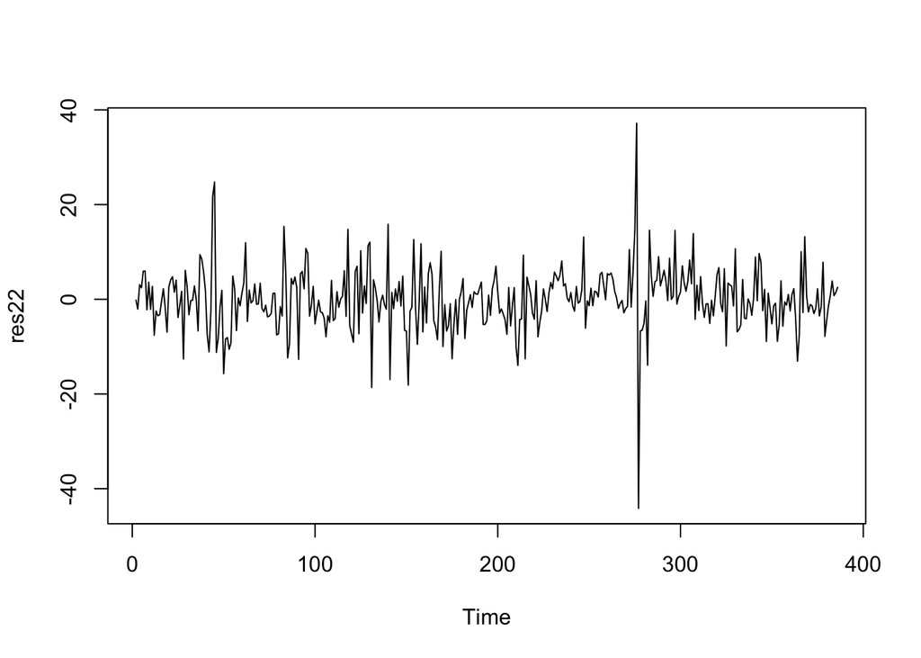

```r
#résidus du modèle estimé
res22<-ar2ma2$residuals
plot(res22)
```

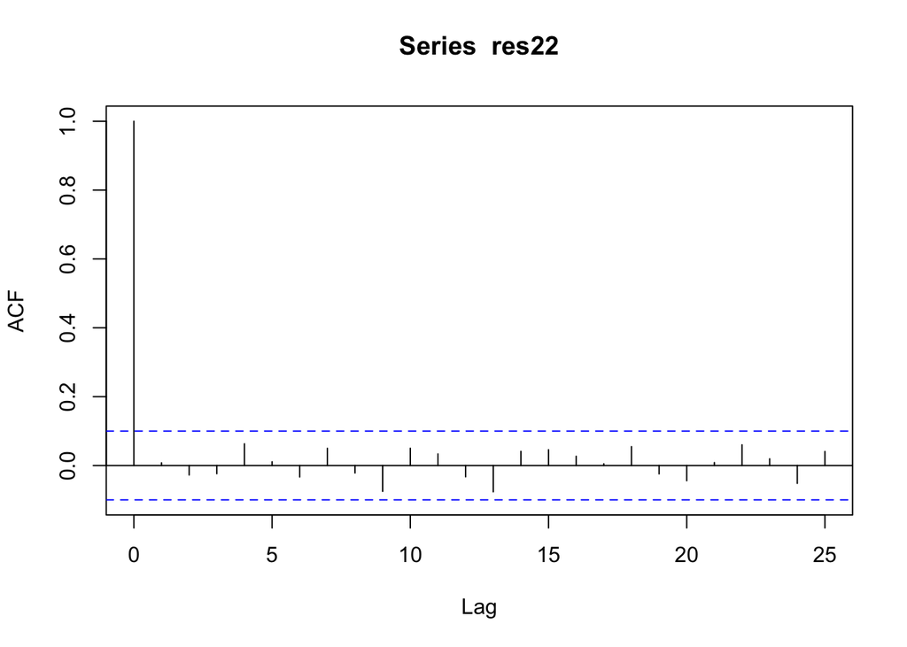

```r
acf(res22) #autocorrélations totales
```

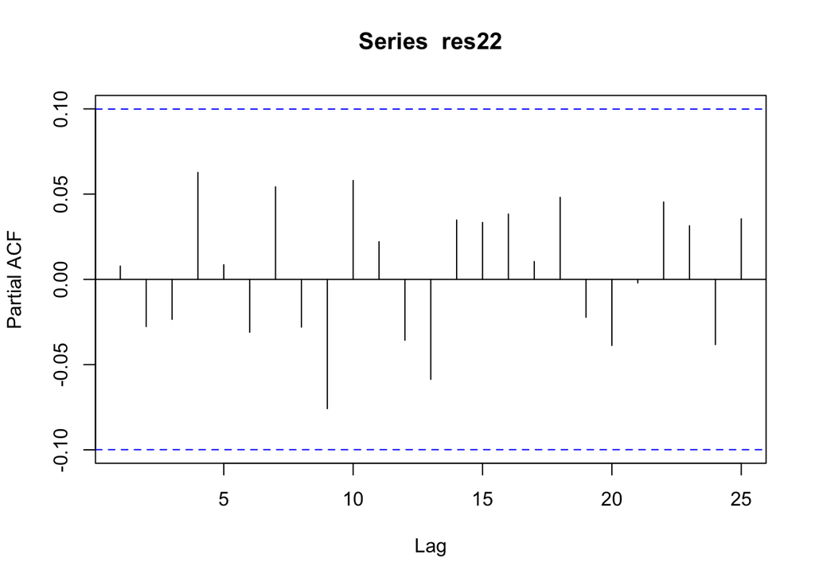

```r
pacf(res22) #autocorrélations partielles
```

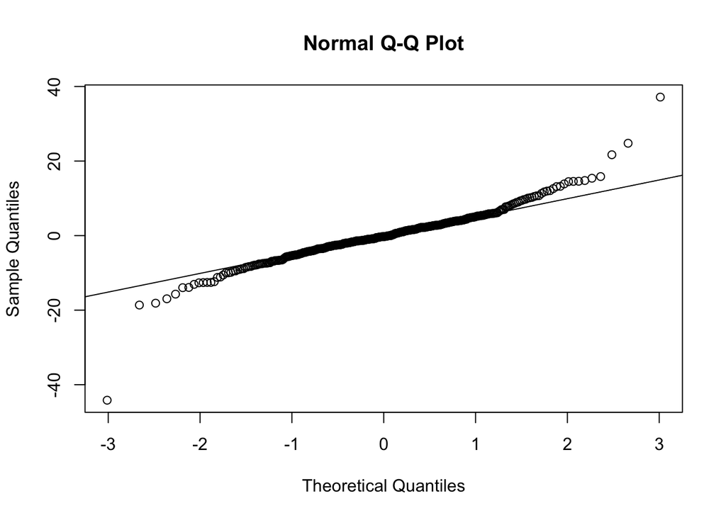

```r
#Test de normalité des résidus
qqnorm(res22)
qqline(res22)
```

#### Q.8

Question ouverte :

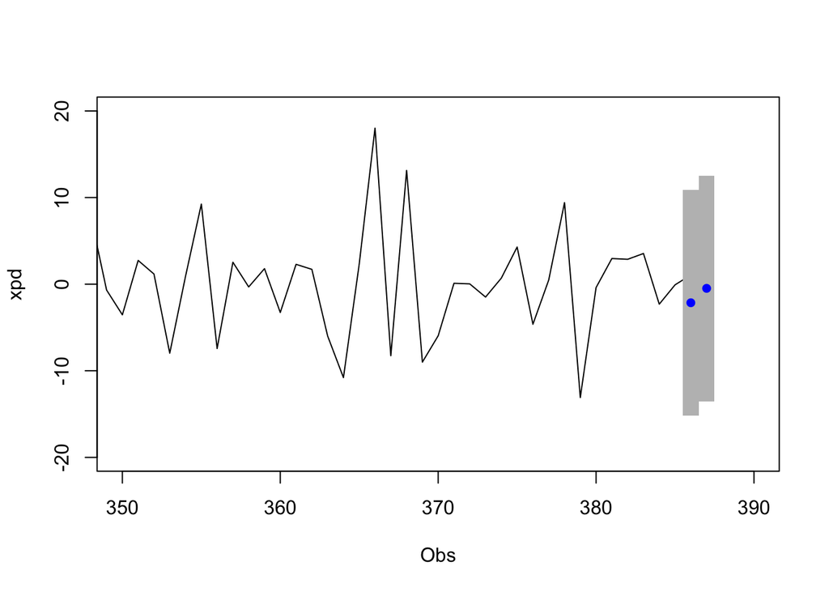

```r
#Prédictions et représentation graphique
pred<-predict(ar2ma2,2)$pred
eps<-mean((res22)^2)-mean(res22)^2

plot(xpd,xlim=c(350,390),ylim=c(-20,20),xlab="Obs")

#IC à 95% sur X(T+1)
rect(xleft = 385.5,xright = 386.5,
     ybottom = as.numeric(pred[1])-sqrt(eps)*qnorm(1-0.05/2,mean=0,sd=1),
     ytop = as.numeric(pred[1])+sqrt(eps)*qnorm(1-0.05/2,mean=0,sd=1),col="gray"
     ,border=NA )
points(x=386,y=as.numeric(pred[1]),col="blue",pch=16)

#IC à 95% sur X(T+2)
rect(xleft = 386.5,xright = 387.5,
     ybottom = as.numeric(pred[2])-sqrt(eps)*qnorm(1-0.05/2,mean=0,sd=1),
     ytop = as.numeric(pred[2])+sqrt(eps)*qnorm(1-0.05/2,mean=0,sd=1),col="gray"
     ,border=NA )
points(x=387,y=as.numeric(pred[2]),col="blue",pch=16)
```